# FSEP data meetup

Julian Trachsel

March 26, 2019

## Hello!

Greetings. Thank you for your interest in this group. This should be fun.

I thought the main focus of this meeting could be to discuss topics for future meetings. But first, just to get the blood moving, lets go through a little exercise where we clean some data, move it between wide and long formats, plot it, run some simple tests and move it back to the wide format.

### Disclaimer

> There are many ways to do things in R, this is by no means the “right” way to do these tasks, just suggestions.

In putting together this tutorial I realized I don’t really know what tidy data is… So take what you read here with a grain of salt. If you want to learn more this: https://r4ds.had.co.nz/tidy-data.html is a great resource (the whole book is free).

Instead of pretending to understand what makes data tidy, I will cover moving your data between ‘long’ and ‘wide’ and hopefully show you why each format is valuable.

You’re going to see this `%>%` a lot. This is called a pipe and is used a whole bunch in the tidyverse.

It is analogous to `|` if you are familiar with bash scripting. It passes the previous data to the next function or command

shortcuts for it are CTRL + SHIFT + M for windows or CMD + SHIFT + M for mac

##### Let’s begin

This dataset is some flow cytometry data collected by Sam, It has the following markers:

- Live-Dead
- CD3
- CD4
- CD8a
- CD25
- FoxP3

First we will read in the data:

```r
CD3 <- read_csv('CD3pos.csv')
CD3[1:3,1:3]
```

```
## # A tibble: 3 x 3
##   Sample                 `CD3+/CD4-/CD8a+/FoxP3-/… `CD3+/CD4-/CD8a+/FoxP3+…
##   <chr>                                      <dbl>                    <dbl>
## 1 Specimen_67 PBMC_A1_A…                       165                       81
## 2 Specimen_67 cec_C1_C0…                       433                       39
## 3 Specimen_67 ln_B1_B01…                       179                      404
```

Not a bad looking dataset… needs a little cleaning thought. The metadata is all locked up in one column. Let’s free it.

```r
CD3$pignum <- sub('Specimen_([0-9]+) ([A-Za-z]+)_.*','\\1', CD3$Sample)  # some regular expressions to extract metadata from sample names

CD3$tissue <- sub('Specimen_([0-9]+) ([A-Za-z]+)_.*','\\2', CD3$Sample)

CD3$treatment <- ifelse(CD3$pignum %in% c(67:73), 'control', 'RPS')      # adding in treatment groups...

CD3 <- CD3 %>% select(pignum, tissue, treatment, everything(), -Sample)  # ordering the dataframe so metadata is first, also dropping "Sample" column

CD3
```

```
## # A tibble: 41 x 19
##    pignum tissue treatment `CD3+/CD4-/CD8a… `CD3+/CD4-/CD8a…
##    <chr>  <chr>  <chr>                <dbl>            <dbl>
##  1 67     PBMC   control                165               81
##  2 67     cec    control                433               39
##  3 67     ln     control                179              404
##  4 68     PBMC   control                 68               84
##  5 68     cec    control                360                7
##  6 68     ln     control                107              156
##  7 69     PBMC   control                361              364
##  8 69     cec    control               5231               37
##  9 69     ln     control                109              343
## 10 70     PBMC   control                338              291
## # … with 31 more rows, and 14 more variables:
## #   `CD3+/CD4-/CD8a+/FoxP3+/CD25-` <dbl>,
## #   `CD3+/CD4-/CD8a+/FoxP3-/CD25-` <dbl>,
## #   `CD3+/CD4+/CD8a+/FoxP3-/CD25+` <dbl>,
## #   `CD3+/CD4+/CD8a+/FoxP3+/CD25+` <dbl>,
## #   `CD3+/CD4+/CD8a+/FoxP3+/CD25-` <dbl>,
## #   `CD3+/CD4+/CD8a+/FoxP3-/CD25-` <dbl>,
## #   `CD3+/CD4+/CD8a-/FoxP3-/CD25+` <dbl>,
## #   `CD3+/CD4+/CD8a-/FoxP3+/CD25+` <dbl>,
## #   `CD3+/CD4+/CD8a-/FoxP3+/CD25-` <dbl>,
## #   `CD3+/CD4+/CD8a-/FoxP3-/CD25-` <dbl>,
## #   `CD3+/CD4-/CD8a-/FoxP3-/CD25+` <dbl>,
## #   `CD3+/CD4-/CD8a-/FoxP3+/CD25+` <dbl>,
## #   `CD3+/CD4-/CD8a-/FoxP3+/CD25-` <dbl>,
## #   `CD3+/CD4-/CD8a-/FoxP3-/CD25-` <dbl>
```

Nice. Now we are ready to move into the “long” format. To do this we use the function `gather()`. Don’t worry if you have trouble remembering how to use this function, I still look it up almost everytime I use it. Basically `gather()` uses key, value pairs to combine all the variables you didn’t specifically omit into one new column. Usually you omit the metadata.

```r
# convert to long format (), This data would be considered tidy?
CD3 %>% gather(key = 'cell_type', value = 'num_events', -c(1:3))
```

```
## # A tibble: 656 x 5
##    pignum tissue treatment cell_type                    num_events
##    <chr>  <chr>  <chr>     <chr>                             <dbl>
##  1 67     PBMC   control   CD3+/CD4-/CD8a+/FoxP3-/CD25+        165
##  2 67     cec    control   CD3+/CD4-/CD8a+/FoxP3-/CD25+        433
##  3 67     ln     control   CD3+/CD4-/CD8a+/FoxP3-/CD25+        179
##  4 68     PBMC   control   CD3+/CD4-/CD8a+/FoxP3-/CD25+         68
##  5 68     cec    control   CD3+/CD4-/CD8a+/FoxP3-/CD25+        360
##  6 68     ln     control   CD3+/CD4-/CD8a+/FoxP3-/CD25+        107
##  7 69     PBMC   control   CD3+/CD4-/CD8a+/FoxP3-/CD25+        361
##  8 69     cec    control   CD3+/CD4-/CD8a+/FoxP3-/CD25+       5231
##  9 69     ln     control   CD3+/CD4-/CD8a+/FoxP3-/CD25+        109
## 10 70     PBMC   control   CD3+/CD4-/CD8a+/FoxP3-/CD25+        338
## # … with 646 more rows
```

```r
CD3.long <- CD3 %>% gather(key = 'cell_type', value = 'num_events', -c(1:3))
```

As you can see the data is now much longer than before. Why is this useful? Hopefully you will see below.

Once you have the data in a long format you can use all kinds of tidyverse verbs to manipulate the data.  
Here we are turning counts into percent_CD3 using the `group_by()` and `mutate` functions.

- `group_by()` allows you to specify how to group your data so that other verbs respect these groupings.
- `mutate()` adds a new column to your dataframe.
- `select()` includes or omits columns.

### This Block below reads as follows:

1. Using the dataframe `CD3.long`, establish groups based on combinations of pignum and tissue.
2. Create a new variable named `percent_CD3` which is the variable `num_events` divided by the sum of all the events (in each group of tissue and pig) * 100
3. remove the old column `num_events`
4. remove the groupings we applied at the beginning. Grouped dataframes remain grouped and can cause some weird stuff if you don’t realize it.

```r
CD3.long <- CD3.long %>% group_by(pignum, tissue) %>%
                     mutate(percent_CD3 = (num_events / sum(num_events)) * 100) %>%
                     select(-num_events) %>% ungroup()
```

One last little cleanup we might want to do is to remove the ‘/’ characters from the `cell_types` column as well as the ‘CD3+’ portion of `cell_types` since all of these cells are CD3+. `mutate()` will overwrite existing variables.

```r
CD3.long <- CD3.long %>% mutate(cell_type=gsub('/','', cell_type)) %>%
                         mutate(cell_type=gsub('CD3\\+','', cell_type))
```

### Post cleanup analysis

Now that our data is clean and in a long format we can very quickly do some of the most common tasks.

One of the first things I like to do is look at boxplots.

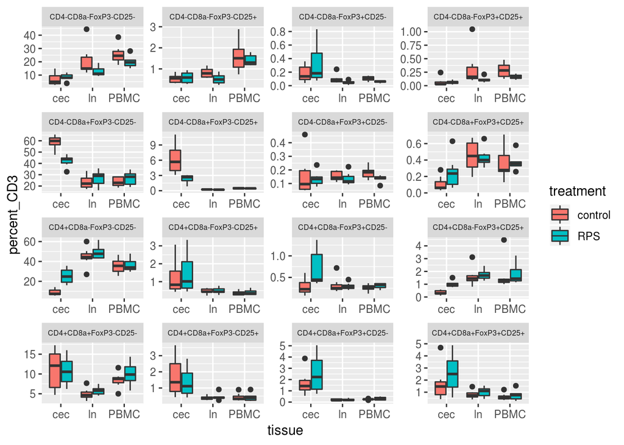

```r
CD3.long %>% ggplot(aes(x=tissue, y=percent_CD3, fill=treatment)) +
                geom_boxplot() + facet_wrap(~cell_type, scales = 'free') + theme(strip.text = element_text(size=6))
```

Very interesting, how about all of the t.tests? T.tests not your thing? Well it’s simple to add in Wilcox tests as well. Now that our data is long, this is all so very easy:

The `summarise()` verb condenses your dataframe, usually based on groupings established by `group_by()`

```r
CD3_tests <- CD3.long %>%
                group_by(tissue, cell_type) %>%
                summarise(wilcox_p=wilcox.test(percent_CD3~treatment)$p.value,
                          t_p=t.test(percent_CD3~treatment)$p.value)

CD3_tests
```

```
## # A tibble: 48 x 4
## # Groups:   tissue [3]
##    tissue cell_type            wilcox_p      t_p
##    <chr>  <chr>                   <dbl>    <dbl>
##  1 cec    CD4-CD8a-FoxP3-CD25- 0.456    0.461
##  2 cec    CD4-CD8a-FoxP3-CD25+ 0.805    0.684
##  3 cec    CD4-CD8a-FoxP3+CD25- 0.456    0.241
##  4 cec    CD4-CD8a-FoxP3+CD25+ 0.456    0.883
##  5 cec    CD4-CD8a+FoxP3-CD25- 0.00117  0.000117
##  6 cec    CD4-CD8a+FoxP3-CD25+ 0.000583 0.0114
##  7 cec    CD4-CD8a+FoxP3+CD25- 0.710    0.700
##  8 cec    CD4-CD8a+FoxP3+CD25+ 0.0530   0.129
##  9 cec    CD4+CD8a-FoxP3-CD25- 0.000583 0.00110
## 10 cec    CD4+CD8a-FoxP3-CD25+ 0.620    0.679
## # … with 38 more rows
```

That’s nice, but maybe we only want to look at data that meets some arbitrary pvalue.

```r
# only cell types with a sig wilcox.test
CD3_sigs <- CD3_tests %>% filter(wilcox_p < 0.05)


CD3_sigs
```

```
## # A tibble: 8 x 4
## # Groups:   tissue [2]
##   tissue cell_type            wilcox_p      t_p
##   <chr>  <chr>                   <dbl>    <dbl>
## 1 cec    CD4-CD8a+FoxP3-CD25- 0.00117  0.000117
## 2 cec    CD4-CD8a+FoxP3-CD25+ 0.000583 0.0114
## 3 cec    CD4+CD8a-FoxP3-CD25- 0.000583 0.00110
## 4 cec    CD4+CD8a-FoxP3+CD25- 0.0379   0.0395
## 5 cec    CD4+CD8a-FoxP3+CD25+ 0.000583 0.000134
## 6 ln     CD4-CD8a-FoxP3-CD25+ 0.0262   0.0352
## 7 ln     CD4-CD8a-FoxP3+CD25- 0.0379   0.0980
## 8 ln     CD4-CD8a-FoxP3+CD25+ 0.0262   0.151
```

How about we plot only the `cell_type`s that meet our pvalue threshold: Here we use the `filter()` verb to select only the rows that meet our condition : `cell_type %in% CD3_sigs$cell_type`

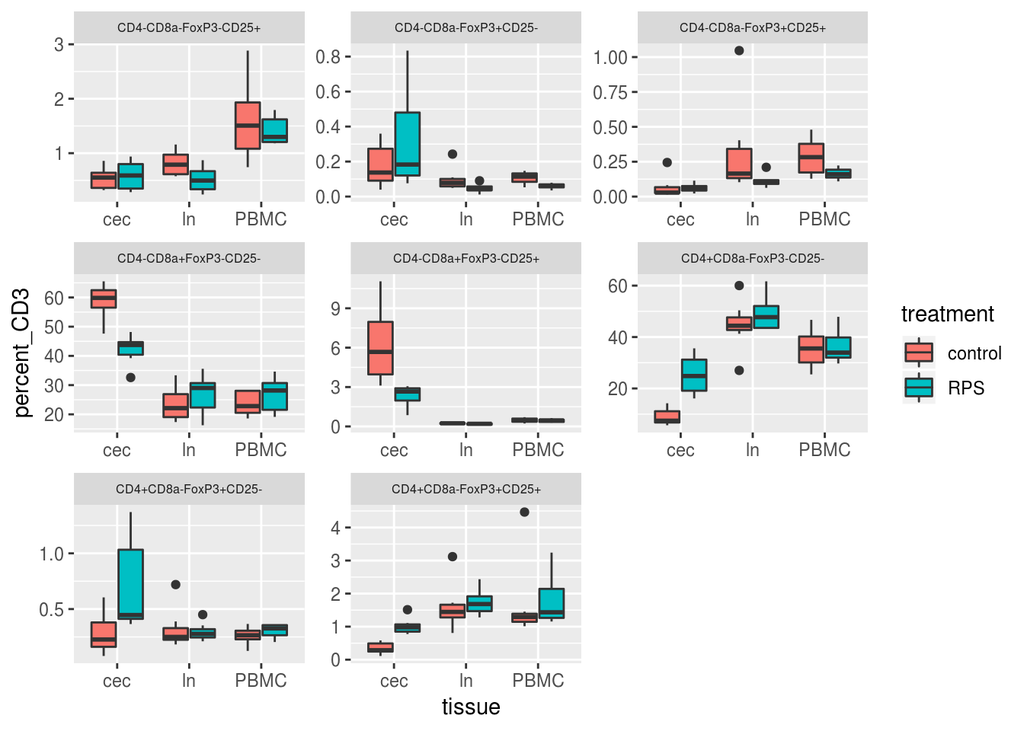

```r
CD3.long %>% filter(cell_type %in% CD3_sigs$cell_type) %>%
  ggplot(aes(x=tissue, y=percent_CD3, fill=treatment)) +
    geom_boxplot() + facet_wrap(~cell_type, scales = 'free') + theme(strip.text = element_text(size=6))
```

Boxplots not your thing?

How about we calculate some summary statistics and plot those intsead:

```r
CD3_summary <- CD3.long %>% group_by(tissue, treatment, cell_type) %>%
                  summarise(avg=mean(percent_CD3),
                    std_dev= sd(percent_CD3),
                    num_obs= n(),
                    std_err=std_dev/sqrt(num_obs)) %>% filter(cell_type %in% CD3_sigs$cell_type)

CD3_summary
```

```
## # A tibble: 48 x 7
## # Groups:   tissue, treatment [6]
##    tissue treatment cell_type                avg std_dev num_obs std_err
##    <chr>  <chr>     <chr>                  <dbl>   <dbl>   <int>   <dbl>
##  1 cec    control   CD4-CD8a-FoxP3-CD25+  0.534   0.199        7  0.0750
##  2 cec    control   CD4-CD8a-FoxP3+CD25-  0.181   0.121        7  0.0456
##  3 cec    control   CD4-CD8a-FoxP3+CD25+  0.0677  0.0811       7  0.0307
##  4 cec    control   CD4-CD8a+FoxP3-CD25- 58.7     5.91         7  2.23
##  5 cec    control   CD4-CD8a+FoxP3-CD25+  6.24    2.91         7  1.10
##  6 cec    control   CD4+CD8a-FoxP3-CD25-  9.02    3.23         7  1.22
##  7 cec    control   CD4+CD8a-FoxP3+CD25-  0.285   0.189        7  0.0716
##  8 cec    control   CD4+CD8a-FoxP3+CD25+  0.350   0.172        7  0.0652
##  9 cec    RPS       CD4-CD8a-FoxP3-CD25+  0.588   0.273        7  0.103
## 10 cec    RPS       CD4-CD8a-FoxP3+CD25-  0.328   0.283        7  0.107
## # … with 38 more rows
```

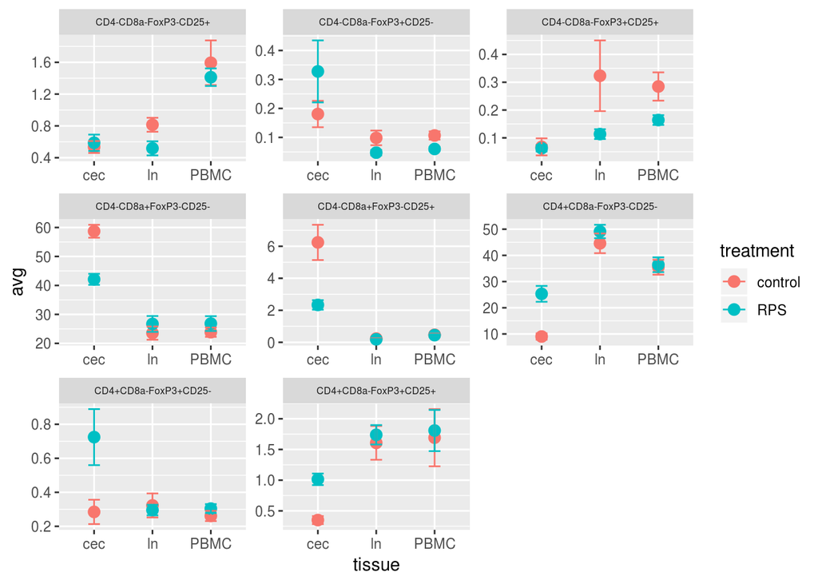

```r
CD3_summary %>% ggplot(aes(x=tissue, y=avg, color=treatment)) +
  geom_point(size=3) + geom_errorbar(aes(ymin=avg-std_err, ymax=avg+std_err), width=.2) +
  facet_wrap(~cell_type, scales = 'free') + theme(strip.text = element_text(size=6))
```

Pretty cool…

How about if you have a favorite cell type you want to plot by itself:

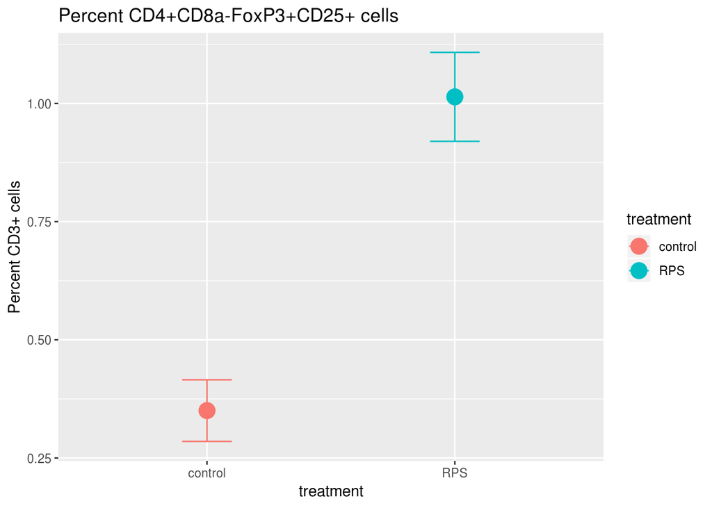

```r
CD3_summary %>% filter(cell_type == 'CD4+CD8a-FoxP3+CD25+' & tissue == 'cec') %>%
  ggplot(aes(x=treatment, y=avg, color=treatment)) + geom_errorbar(aes(ymin=avg-std_err, ymax= avg+std_err), width=0.2) +
  geom_point(size=5) + ggtitle('Percent CD4+CD8a-FoxP3+CD25+ cells') + ylab('Percent CD3+ cells')
```

Data in the long format is amazing. Why would anyone ever want data that is not long?

- It is a pain to enter data in the long format
- Some tools require data in the wide format ecological statistical techniques often operate on matricies, each ‘species’ or part of the community is a column

The `spread()` verb moves data from long to wide.

```r
CD3.wide <- CD3.long %>% mutate(set=paste(tissue, treatment,sep = '_')) %>%
  spread(key = cell_type, value = percent_CD3)

CD3.wide
```

```
## # A tibble: 41 x 20
##    pignum tissue treatment set   `CD4-CD8a-FoxP3… `CD4-CD8a-FoxP3…
##    <chr>  <chr>  <chr>     <chr>            <dbl>            <dbl>
##  1 67     cec    control   cec_…            14.9             0.683
##  2 67     ln     control   ln_c…            44.5             0.789
##  3 67     PBMC   control   PBMC…            24.5             1.79
##  4 68     cec    control   cec_…            10.4             0.859
##  5 68     ln     control   ln_c…            14.4             0.578
##  6 68     PBMC   control   PBMC…            29.5             0.832
##  7 69     cec    control   cec_…             3.05            0.348
##  8 69     ln     control   ln_c…            14.9             1.07
##  9 69     PBMC   control   PBMC…            18.7             1.51
## 10 70     cec    control   cec_…             4.96            0.322
## # … with 31 more rows, and 14 more variables:
## #   `CD4-CD8a-FoxP3+CD25-` <dbl>, `CD4-CD8a-FoxP3+CD25+` <dbl>,
## #   `CD4-CD8a+FoxP3-CD25-` <dbl>, `CD4-CD8a+FoxP3-CD25+` <dbl>,
## #   `CD4-CD8a+FoxP3+CD25-` <dbl>, `CD4-CD8a+FoxP3+CD25+` <dbl>,
## #   `CD4+CD8a-FoxP3-CD25-` <dbl>, `CD4+CD8a-FoxP3-CD25+` <dbl>,
## #   `CD4+CD8a-FoxP3+CD25-` <dbl>, `CD4+CD8a-FoxP3+CD25+` <dbl>,
## #   `CD4+CD8a+FoxP3-CD25-` <dbl>, `CD4+CD8a+FoxP3-CD25+` <dbl>,
## #   `CD4+CD8a+FoxP3+CD25-` <dbl>, `CD4+CD8a+FoxP3+CD25+` <dbl>
```

Now that our data is wide again. Lets look at how similar the whole T-cell communities are to each other.

```r
# you will need to run these commands if you want this next part to work:

# install.packages('vegan') Awesome community ecology package
# devtools::install_github('jtrachsel/funfuns')

library(funfuns)
NMDS <- NMDS_ellipse(metadata = CD3.wide[,1:4], OTU_table = CD3.wide[,-c(1:4)],grouping_set = 'set')
```

```
## *** Solution reached
## [1] "Ordination stress: 0.0580135451533682"
```

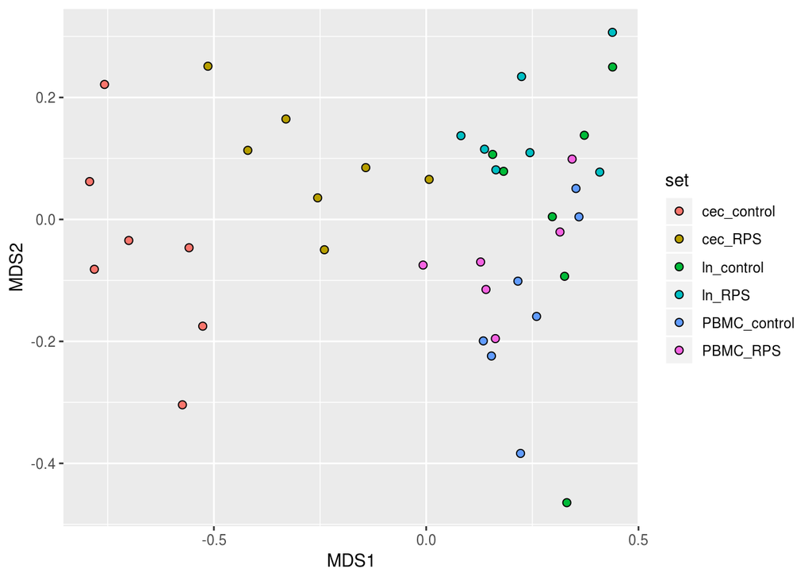

```r
# how similar are these communities?
NMDS[[1]] %>% ggplot(aes(x=MDS1, y=MDS2, fill=set)) + geom_point(shape =21, size=2)
```

Pretty cool… but we can add a few more things that will really help see some neat groupings in our data.

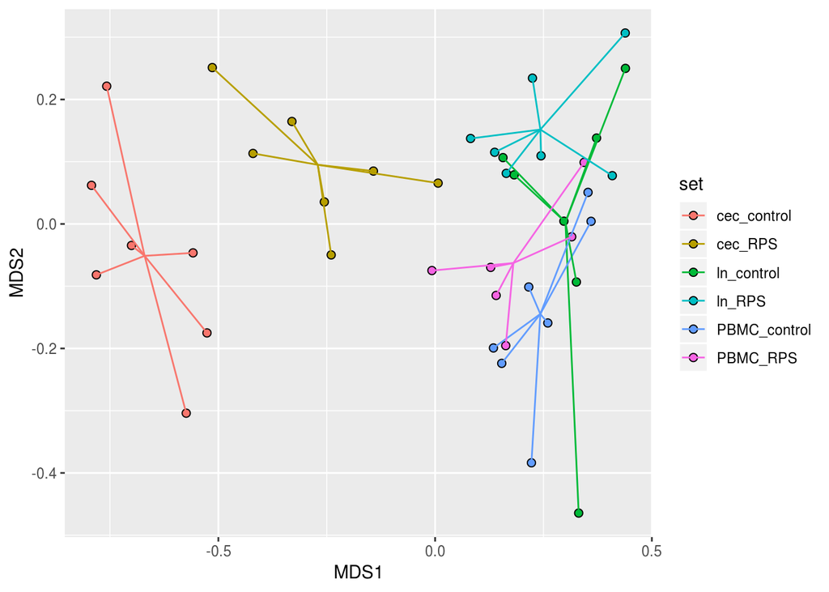

```r
# join our sets with some segments...
NMDS[[1]] %>% ggplot(aes(x=MDS1, y=MDS2, fill=set)) + geom_point(shape =21, size=2) +
  geom_segment(aes(xend=centroidX, yend=centroidY, color=set))
```

And finally:

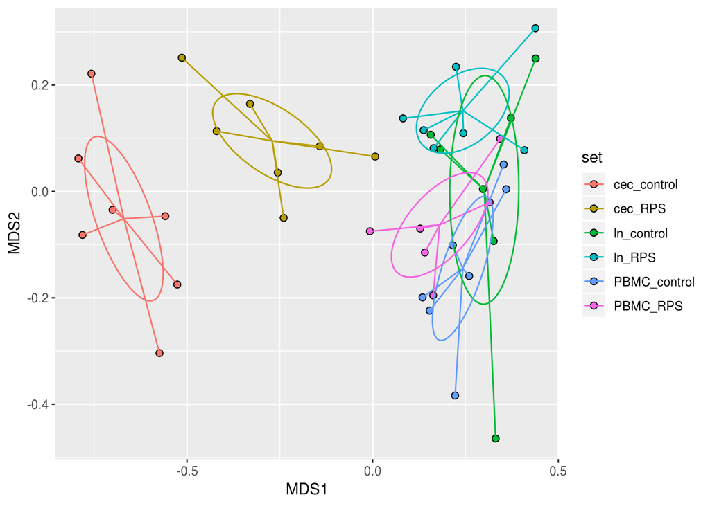

```r
# add in some standard error elipses...
NMDS[[1]] %>% ggplot(aes(x=MDS1, y=MDS2, fill=set)) + geom_point(shape =21, size=2) +
  geom_segment(aes(xend=centroidX, yend=centroidY, color=set)) +
  geom_path(data = NMDS[[2]], aes(x=NMDS1, y=NMDS2, color=group), inherit.aes = FALSE)
```

Nice. We couldn’t do this easily with long format data.